# Genome-wide perturb-seq

```python
from scdataloader import Preprocessor

from bengrn import BenGRN, get_perturb_gt, compute_genie3
from bengrn.base import train_classifier
from grnndata import utils as grnutils

from anndata.utils import make_index_unique
import pandas as pd
import numpy as np
import scanpy as sc

%load_ext autoreload
%autoreload 2

import torch
torch.set_float32_matmul_precision('medium')
```

from scdataloader import Preprocessor from bengrn import BenGRN, get_perturb_gt, compute_genie3 from bengrn.base import train_classifier from grnndata import utils as grnutils from anndata.utils import make_index_unique import pandas as pd import numpy as np import scanpy as sc %load_ext autoreload %autoreload 2 import torch torch.set_float32_matmul_precision('medium')

[output not shown]

```
💡 connected lamindb: jkobject/scprint
```

```python
adata = get_perturb_gt()

adata.var["isTF"] = False
adata.var.loc[adata.var.gene_name.isin(grnutils.TF), "isTF"] = True
adata.var["isTF"].sum()
```

adata = get_perturb_gt() adata.var["isTF"] = False adata.var.loc[adata.var.gene_name.isin(grnutils.TF), "isTF"] = True adata.var["isTF"].sum()

[output not shown]

[output cut: 13 more lines]

[output not shown]

```
650
```

```python
preprocessor = Preprocessor(force_preprocess=True, skip_validate=True,
                            do_postp=False, min_valid_genes_id=5000, min_dataset_size=64)
nadata = preprocessor(adata.copy())
NUM_GENES = 5000
NUM_CELLS = 1024
adata
```

preprocessor = Preprocessor(force_preprocess=True, skip_validate=True, do_postp=False, min_valid_genes_id=5000, min_dataset_size=64) nadata = preprocessor(adata.copy()) NUM_GENES = 5000 NUM_CELLS = 1024 adata

```
Dropping layers:  KeysView(Layers with keys: )
checking raw counts
```

```
removed 0 non primary cells, 10691 renamining
```

```
filtered out 0 cells, 10691 renamining
Removed 8 genes.
```

```
startin QC
```

```
Seeing 10068 outliers (94.17% of total dataset):
done
```

```
GRnnData object with n_obs × n_vars = 10691 × 8563
    obs: 'gem_group', 'gene', 'gene_id', 'transcript', 'gene_transcript', 'sgID_AB', 'mitopercent', 'UMI_count', 'z_gemgroup_UMI', 'core_scale_factor', 'core_adjusted_UMI_count', 'organism_ontology_term_id'
    var: 'gene_name', 'chr', 'start', 'end', 'class', 'strand', 'length', 'in_matrix', 'mean', 'std', 'cv', 'fano', 'isTF'
    varp: 'GRN'
    with a grn of 1115065 elements
```

```python
sc.pp.highly_variable_genes(adata, flavor="seurat_v3", n_top_genes=NUM_GENES)
adata.var['symbol'] = adata.var["gene_name"]
adata.var['ensembl_id'] = adata.var.index
subadata = adata[:NUM_CELLS, adata.var.highly_variable]
del subadata.varp['GRN']
```

sc.pp.highly_variable_genes(adata, flavor="seurat_v3", n_top_genes=NUM_GENES) adata.var['symbol'] = adata.var["gene_name"] adata.var['ensembl_id'] = adata.var.index subadata = adata[:NUM_CELLS, adata.var.highly_variable] del subadata.varp['GRN']

```python
metrics = {}
```

metrics = {}

```python
genie_grn = compute_genie3(subadata, nthreads=20)
genie_grn.var.index = subadata.var.index
metrics['genie3_perturb'] = BenGRN(genie_grn, do_auc=True, doplot=True).compare_to(other=adata)
```

genie_grn = compute_genie3(subadata, nthreads=20) genie_grn.var.index = subadata.var.index metrics['genie3_perturb'] = BenGRN(genie_grn, do_auc=True, doplot=True).compare_to(other=adata)

```
Tree method: RF
K: sqrt
Number of trees: 100


running jobs on 20 threads
```

```
Elapsed time: 487.89 seconds
```

```
precision:  0.021411638790563244
recall:  0.9659762797288713
random precision: 0.020718126571001305
```

```
Area Under Precision-Recall Curve (AUPRC):  0.03565161597739377
```

```
EPR: 3.54075467253788
```

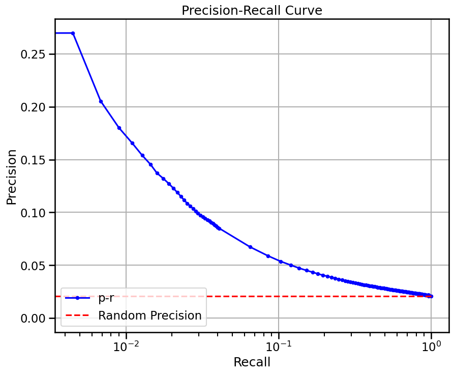

```python
genie_grn.var.index = make_index_unique(genie_grn.var['symbol'].astype(str))
metrics['genie3_perturb_base'] = BenGRN(genie_grn, do_auc=True, doplot=True).scprint_benchmark()
```

genie_grn.var.index = make_index_unique(genie_grn.var['symbol'].astype(str)) metrics['genie3_perturb_base'] = BenGRN(genie_grn, do_auc=True, doplot=True).scprint_benchmark()

```
base enrichment
```

```
Top central genes: []
```

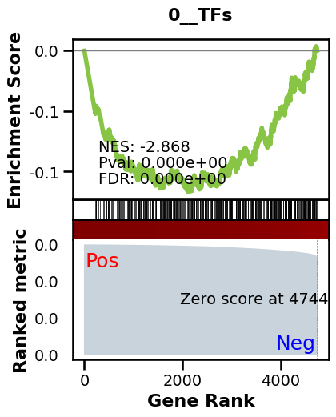

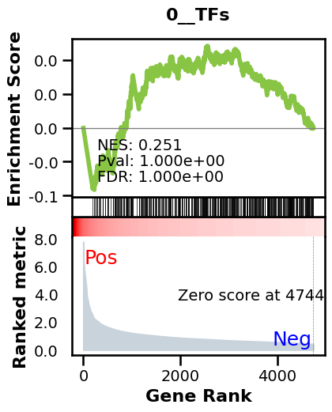

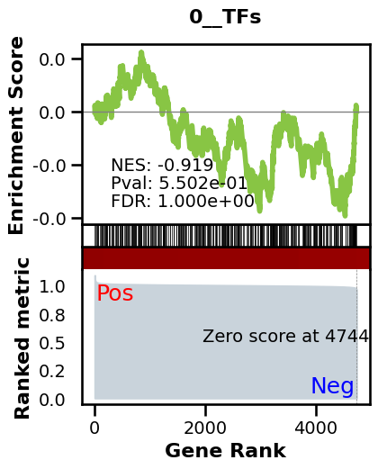

```
_________________________________________
TF specific enrichment
```

```
found some significant results for  19.642857142857142 % TFs

_________________________________________
loading GT,  omnipath
```

```
intersection of 3261 genes
intersection pct: 0.687249736564805
precision:  0.0016940474499637448
recall:  0.9264697414636955
random precision: 0.0016326385571186594
```

```
Area Under Precision-Recall Curve (AUPRC):  0.0018857828449403108
EPR: 3.988476397763414
```

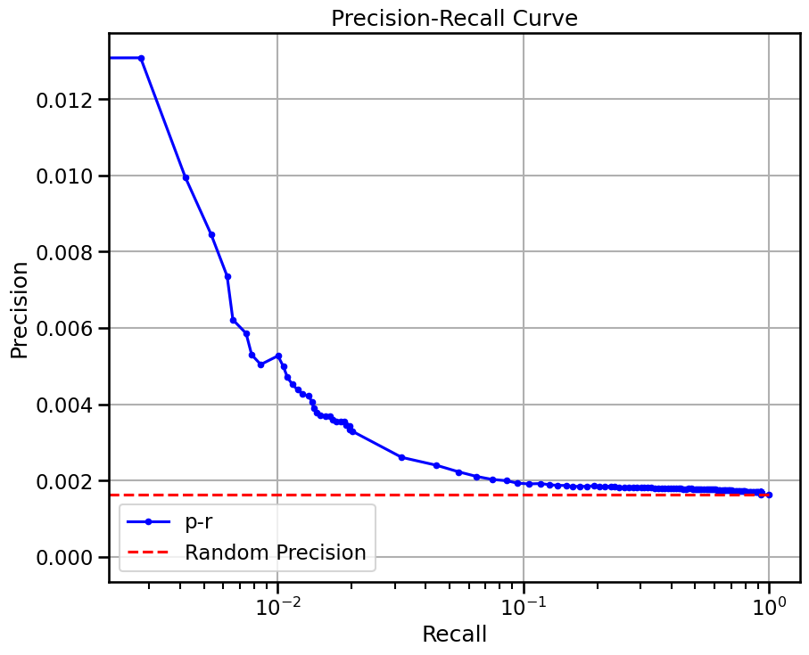

```python
genie_grn = compute_genie3(subadata, nthreads=20,
                           regulators=adata.var[adata.var.isTF].index.tolist())
genie_grn.var.index = subadata.var.index
metrics['genie3_tf_perturb'] = BenGRN(genie_grn, do_auc=True, doplot=True).compare_to(other=adata)
```

genie_grn = compute_genie3(subadata, nthreads=20, regulators=adata.var[adata.var.isTF].index.tolist()) genie_grn.var.index = subadata.var.index metrics['genie3_tf_perturb'] = BenGRN(genie_grn, do_auc=True, doplot=True).compare_to(other=adata)

```
Tree method: RF
K: sqrt
Number of trees: 100


running jobs on 20 threads
```

```
Elapsed time: 129.73 seconds
```

```
precision:  0.015117823033483179
recall:  0.05607212414399698
random precision: 0.020718126571001305
```

```
Area Under Precision-Recall Curve (AUPRC):  0.020825095462878654
EPR: 1.0667829823965929
```

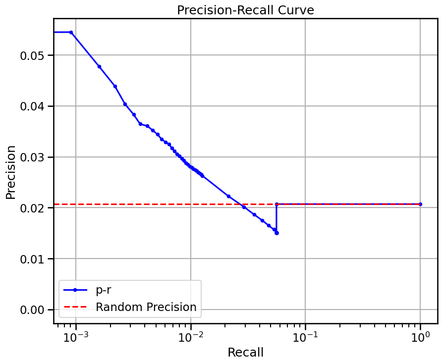

```python
genie_grn.var.index = make_index_unique(genie_grn.var['symbol'].astype(str))
metrics['genie3_tf_perturb_base'] = BenGRN(genie_grn, do_auc=True, doplot=True).scprint_benchmark()
```

genie_grn.var.index = make_index_unique(genie_grn.var['symbol'].astype(str)) metrics['genie3_tf_perturb_base'] = BenGRN(genie_grn, do_auc=True, doplot=True).scprint_benchmark()

```
base enrichment
```

```
Top central genes: []
```

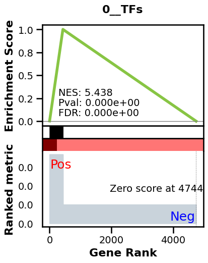

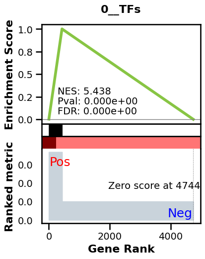

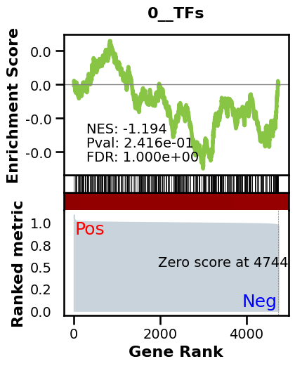

```
_________________________________________
TF specific enrichment
```

```
found some significant results for  5.357142857142857 % TFs

_________________________________________
loading GT,  omnipath
```

```
intersection of 3261 genes
intersection pct: 0.687249736564805
precision:  0.008115454691164588
recall:  0.5714285714285714
random precision: 0.0016326385571186594
```

```
Area Under Precision-Recall Curve (AUPRC):  0.00818330800021221
EPR: 17.297946276803675
```

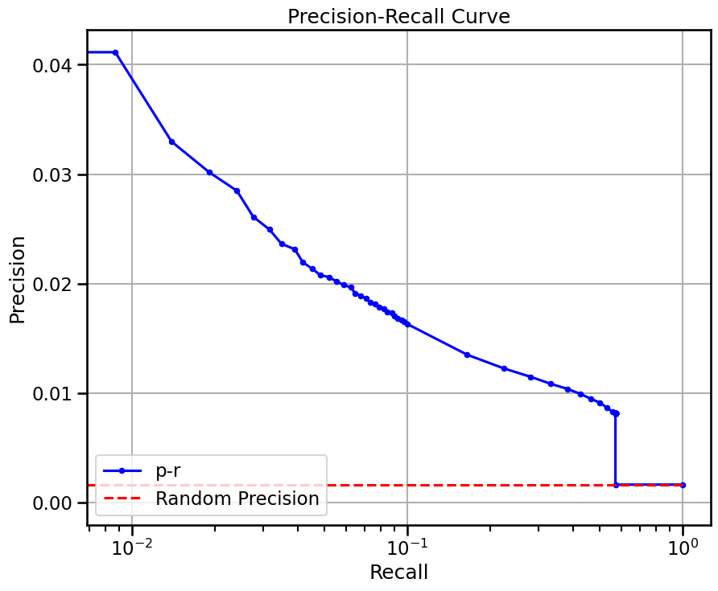

```python
metrics
```

metrics

```
{'genie3_perturb': {'precision': 0.021411638790563244,
  'recall': 0.9659762797288713,
  'rand_precision': 0.020718126571001305,
  'auprc': 0.03565161597739377,
  'epr': 3.54075467253788},
 'genie3_perturb_base': {'TF_enr': True,
  'significant_enriched_TFtargets': 19.642857142857142,
  'precision': 0.0016940474499637448,
  'recall': 0.9264697414636955,
  'rand_precision': 0.0016326385571186594,
  'auprc': 0.0018857828449403108,
  'epr': 3.988476397763414},
 'genie3_tf_perturb': {'precision': 0.015117823033483179,
  'recall': 0.05607212414399698,
  'rand_precision': 0.020718126571001305,
  'auprc': 0.020825095462878654,
  'epr': 1.0667829823965929},
 'genie3_tf_perturb_base': {'enriched_terms_Central': ['0__TFs',
   'celltype.gmt__Embryonic stem cells',
   'celltype.gmt__Enteric neurons',
   'celltype.gmt__Mesangial cells',
   'celltype.gmt__Tuft cells',
   'celltype.gmt__Satellite cells',
   'celltype.gmt__Radial glial cells'],
  'TF_enr': True,
  'significant_enriched_TFtargets': 5.357142857142857,
  'precision': 0.008115454691164588,
  'recall': 0.5714285714285714,
  'rand_precision': 0.0016326385571186594,
  'auprc': 0.00818330800021221,
  'epr': 17.297946276803675}}
```

```python
import pandas as pd
```

import pandas as pd

```python
res = []
res2 = []
for k, v in metrics.items():
    if k.split('_')[-1] == "base":
        res2.append([k.split('_')[-2], v['epr'], v['auprc'], v['rand_precision'], v['significant_enriched_TFtargets'], v.get('TF_enr', False), 'tf_' in k])
    else:
        res.append([k.split('_')[-1], v['epr'], v['auprc'], v['rand_precision'], 'tf_' in k])

df = pd.DataFrame(res, columns=['name','EPR', 'AUPRC', 'RAND', 'TF_only'])
df2 = pd.DataFrame(res2, columns=['name','EPR', 'AUPRC', 'RAND', 'TF_targ', 'TF_enr', 'TF_only'])
df
```

res = [] res2 = [] for k, v in metrics.items(): if k.split('_')[-1] == "base": res2.append([k.split('_')[-2], v['epr'], v['auprc'], v['rand_precision'], v['significant_enriched_TFtargets'], v.get('TF_enr', False), 'tf_' in k]) else: res.append([k.split('_')[-1], v['epr'], v['auprc'], v['rand_precision'], 'tf_' in k]) df = pd.DataFrame(res, columns=['name','EPR', 'AUPRC', 'RAND', 'TF_only']) df2 = pd.DataFrame(res2, columns=['name','EPR', 'AUPRC', 'RAND', 'TF_targ', 'TF_enr', 'TF_only']) df

|  | name | EPR | AUPRC | RAND | TF_only |
| --- | --- | --- | --- | --- | --- |
| 0 | perturb | 3.540755 | 0.035652 | 0.020718 | False |
| 1 | perturb | 1.066783 | 0.020825 | 0.020718 | True |

```python
df2
```

df2

|  | name | EPR | AUPRC | RAND | TF_targ | TF_enr | TF_only |
| --- | --- | --- | --- | --- | --- | --- | --- |
| 0 | perturb | 3.988476 | 0.001886 | 0.001633 | 19.642857 | True | False |
| 1 | perturb | 17.297946 | 0.008183 | 0.001633 | 5.357143 | True | True |